# Boletim Macro Semanal

Data de referência: 2026-10-12

## Quadro

Quadro-resumo dos indicadores acompanhados nesta semana. Data de referência do boletim: 2026-10-12. Cada indicador traz o seu próprio mês ou dia de referência: o IPCA é de 09/2026 e o IBC-Br é de 07/2026.

| Indicador | Último valor | Var. mês | Var. 12 meses |
| --- | --- | --- | --- |
| IPCA (09/2026) | 0,82% | 0,82% | 4,58% |
| Câmbio R$/US$ (09/10/2026) | R$ 4,99 | -2,02% | -8,36% |
| Selic meta (12/10/2026; % a.a.; variações em p.p.) | 13,75% a.a. | -0,25 p.p. | -1,25 p.p. |
| IBC-Br (07/2026) | 114,40 (índice) | -0,22% (SA, SGS 24364) | 1,48% (original, SGS 24363) |

## Inflação

O Índice Nacional de Preços ao Consumidor Amplo (IPCA), apurado pelo IBGE e coletado via SGS 433, registrou variação de 0,82% em 09/2026, o mês mais recente disponível para a série. No acumulado do ano, a alta é de 3,95%; em doze meses, 4,58%.

IPCA acumulado em 12 meses: **4,58%** (09/2026). O índice está **acima do teto** da banda de 1,50% a 4,50%, pelo 1º mês consecutivo. São 6 meses seguidos fora que caracterizam descumprimento e obrigam o presidente do BC a enviar carta aberta ao Ministro da Fazenda. Desde a entrada do regime contínuo, em jan/2025, foram 13 dos 21 meses fora da banda, com sequência máxima de 10 meses consecutivos.

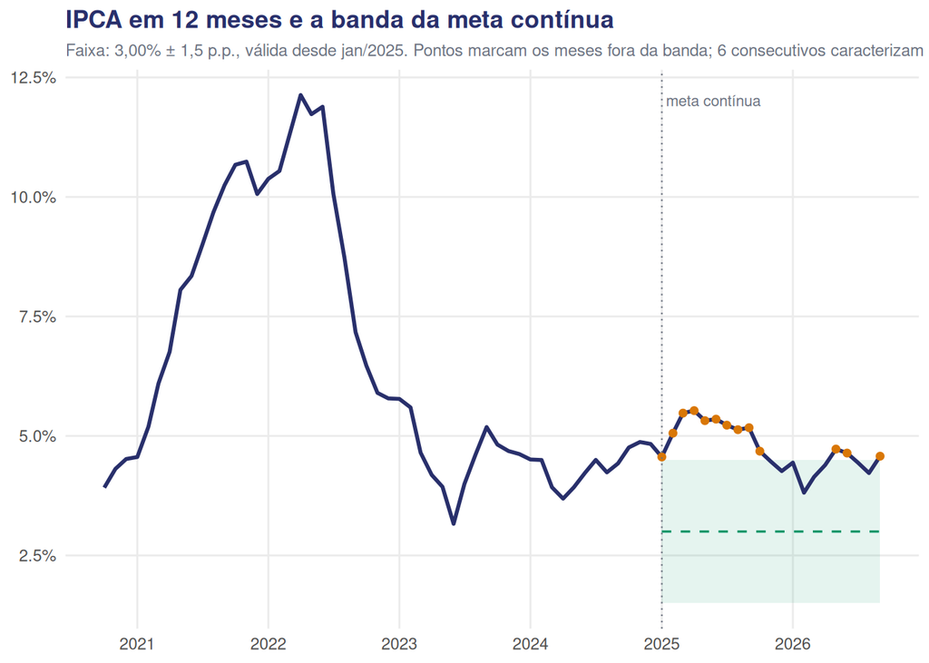

IPCA acumulado em 12 meses e banda da meta contínua (3,00% ± 1,5 p.p., válida desde jan/2025). Fonte: IBGE, via SGS 433.

## Câmbio e juros

### Taxa de câmbio

A taxa de câmbio R$/US$ (SGS 1), cotação de fechamento, está em R$ 4,99 na referência de 09/10/2026. No mês, a cotação recuou 2,02%, o que corresponde à valorização do Real na margem. No acumulado do ano e em doze meses o sentido é o mesmo: queda de 9,33% e de 8,36%, respectivamente.

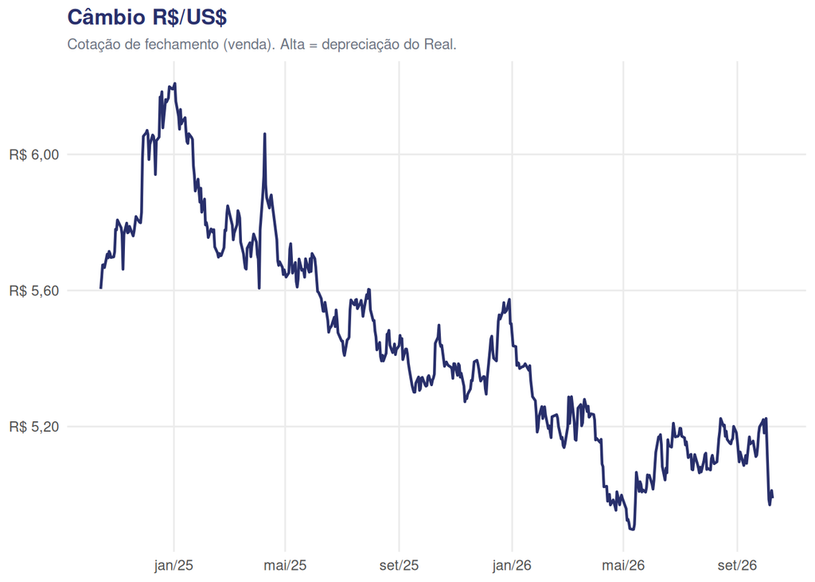

Câmbio R$/US$, cotação diária de fechamento (venda), últimos dois anos. Fonte: Banco Central, SGS 1.

### Taxa Selic

A meta da taxa Selic (SGS 432), definida pelo Copom, está em 13,75% a.a. na referência de 12/10/2026. As variações são reportadas em pontos percentuais (p.p.): -0,25 p.p. no mês, -1,25 p.p. no ano e -1,25 p.p. em doze meses. Os três horizontes apontam recuo da meta.

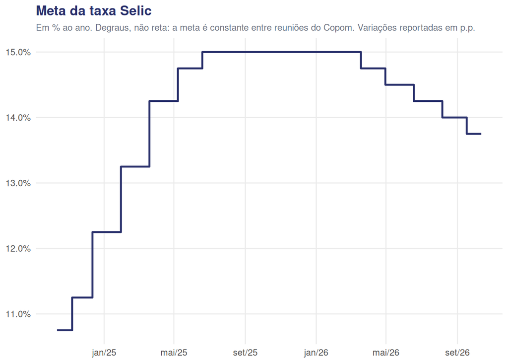

Meta da taxa Selic (% a.a.), em degraus, últimos dois anos. Fonte: Banco Central, SGS 432.

## Atividade

O Índice de Atividade Econômica do Banco Central (IBC-Br) tem como mês de referência mais recente 07/2026, defasado em relação à data deste boletim (2026-10-12).

Na comparação mensal, a série com ajuste sazonal (fonte: Banco Central, SGS 24364) apresenta variação de -0,22% em 07/2026 frente ao mês anterior, uma queda.

No horizonte de doze meses, a série original (fonte: Banco Central, SGS 24363), calculada por média de período, apresenta variação de 1,48%. No acumulado do ano, a mesma série original (SGS 24363), também por média de período, mostra variação de 1,50%. As leituras dessazonalizada (margem) e original (interanual) são reportadas separadamente, sem síntese entre elas.

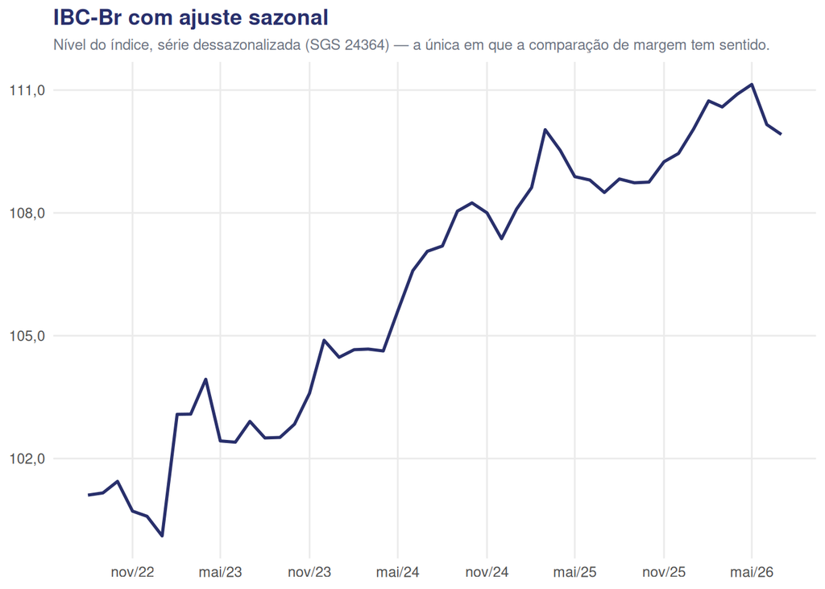

IBC-Br com ajuste sazonal, nível do índice, últimos 48 meses. Fonte: Banco Central, SGS 24364.

*Boletim elaborado com base nos dados disponíveis em 2026-10-12. Fontes primárias: Banco Central do Brasil, Sistema Gerenciador de Séries Temporais (SGS), via `rbcb::get_series`. Séries: IPCA mensal (SGS 433), câmbio R$/US$ (SGS 1), Selic meta (SGS 432), IBC-Br original (SGS 24363) e IBC-Br com ajuste sazonal (SGS 24364).*